# *Palabras que se las lleva el viento*

Exploring the last 10 inauguration speeches of Peruvian presidents

## Introduction

As of this writing, the current Peruvian government counts over 66 deaths in less than 4 months of government (Rebaza and Guy, 2023). Dina Boluarte is Peru’s first female president and the sixth person to occupy the presidential chair in four years (Olmo, 2022). She ascended to office on December 7, 2022, after the previous president, elected by popular vote, dissolved the congress after only 16 months in charge and many attempts of being removed from office by the congress.

The analysis of the political motives of the perpetual peruvian political crisis exceeds the purpose of this exercise. However, it will suffice to mention that, before Boluarte, perhaps the one who aroused the most popular rage was Manuel Merino, who governed alone from November 10 to 15, 2020 —less than a week!— and ended up resigning because of massive protests throughout the country (Redacción BBC Mundo, 2020). The last government that lasted 5 years, the constitutional term of office, was that of Ollanta Humala (2011 - 2016). Since then, mandates have lasted months or even just days.

This exercise aims to characterize the topics and sentiments addressed in the last 10 Message to the Nation (or inaugural speech) in Peru. The hypothesis is that the inaugural speeches, analyzed through text mining techniques, will help to characterize the context in which each president ascended to power, and that there will be clear differences in the topics and length of those who ascended by popular vote, and those who took office by emergency succession. Besides, negative-related sentiments will be predominant in general.

## Data

Dina Boluarte, Francisco Sagasti, Martín Vizcarra and Valentín Paniagua were not elected by popular vote, but assigned for different reasons and in different contexts, with different popular approval. There is also a debate about Alberto Fujimori’s second term: whether he was legitimately elected or manipulated the results in obedience to his dictatorial spirit. On the other hand, Manuel Merino was not considered on purpose: because of the way he took office and his brief period (5 days), many do not consider him a president, only a coup plotter or usurper.

## Dataframe creation

```r
libraries <- c(
  "tidyverse",
  "tidytext",
  "textdata",
  "wordcloud",
  "RColorBrewer",
  "reshape2",
  "igraph",
  "ggraph",
  "widyr",
  "tm",
  "quanteda",
  "quanteda.textplots",
  "topicmodels",
  "syuzhet",
  "parallel",
  "textstem",
  "SentimentAnalysis"
)

# install (in case they are not already installed) and load packages
for (lib in libraries) {
  if (!requireNamespace(lib, quietly = TRUE)) {
    install.packages(lib)
  }
  suppressPackageStartupMessages(library(lib, character.only = TRUE))
}
# remove vector and iterator
rm(lib, libraries)
```

The following steps are to automatically create the download link for each given the username and repository name:

```r
presidents <-
  c("Dina Boluarte",
    "Pedro Castillo",
    "Francisco Sagasti",
    "Martin Vizcarra",
    "Pedro Pablo Kuczynski",
    "Ollanta Humala",
    "Alejandro Toledo",
    "Valentin Paniagua",
    "Alberto Fujimori second term",
    "Alberto Fujimori first term")

links <- paste0(
  "https://raw.githubusercontent.com/carolinacornejocastellano/presidential_text_mining/main/",
  tolower(gsub(" ", "_", presidents)), ".md")
```

Then, a first dataframe without the speeches was created:

```r
df <- tibble(
  president = presidents,
  date = c("2022-12-07",
          "2021-07-28",
          "2020-11-17",
          "2018-03-23",
          "2016-07-28",
          "2011-07-28",
          "2001-07-28",
          "2000-11-11",
          "1995-07-28",
          "1990-07-28"),
  url = links
)
```

After that, the speeches were downloaded from the [GitHub](https://github.com/carolinacornejocastellano/presidential_text_mining) repository. In this way, a dataframe with 3 columns was obtained: president, date and the entire speech in a single line for each president:

```r
df$speech <- df$url %>%
    map_chr(~ read_lines(.x,
      locale = locale(encoding = "UTF-8")) %>%
        paste(collapse = "\n"))

# delete URLs' column from df, as they are not longer needed
df$url <- NULL

df
```

```
## # A tibble: 10 × 3
##    president                    date       speech
##    <chr>                        <chr>      <chr>
##  1 Dina Boluarte                2022-12-07 "Señoras y señores congresistas, que…
##  2 Pedro Castillo               2021-07-28 "Mujeres y hombres de mi amado puebl…
##  3 Francisco Sagasti            2020-11-17 "Queridos compatriotas,queridos ciud…
##  4 Martin Vizcarra              2018-03-23 "Queridos hermanos peruanos, me diri…
##  5 Pedro Pablo Kuczynski        2016-07-28 "Me presento ante el país, según el …
##  6 Ollanta Humala               2011-07-28 "Recibo con humildad y profundo ferv…
##  7 Alejandro Toledo             2001-07-28 "Hermanas y hermanos del Perú;\\\nAm…
##  8 Valentin Paniagua            2000-11-11 "Señores Congresistas:\n\nEn ésta qu…
##  9 Alberto Fujimori second term 1995-07-28 "Al iniciar este Mensaje que, de acu…
## 10 Alberto Fujimori first term  1990-07-28 "La voluntad soberana del pueblo, ex…
```

## Data preparation

The next step was to tokenize the speeches and remove stopwords. Since the language of the speeches is Spanish, it was preferred to conduct the analysis in Spanish. It was considered that translating them could add a degree of bias, since many online translation services perform very literal translations and/or make the real meaning of what was said get lost.

However, as it will be seen later on, analyzing the Spanish texts was a challenge in itself since the packages for stopwords, sentiment analysis, lemmatization and stemming, etc., are mostly built for English corpora, or their default settings are for English. In some cases, it was necessary to add additional parameters or to use other packages to do the same as what it was taught in class.

The stopwords in Spanish were stored in a vector. Then, the speeches column was split into tokens with the `unnest_tokens()` function from the `tidytext` package. Subsequently, the tokens that matched the stopwords stored in the vector were deleted.

```r
stopwords_es <- stopwords::stopwords("es",
  source = "stopwords-iso"
)
```

```r
df_no_stopwords <- df %>%
  unnest_tokens(word, speech) %>%
  anti_join(data.frame(word = stopwords_es),
            by = "word") %>%
  group_by(president, date) %>%
  summarize(clean_speech = paste(word,
                                 collapse = " "))
df_tokenized <- df_no_stopwords %>%
  unnest_tokens(word, clean_speech) %>%
  filter(!word %in% stopwords_es)
```

```r
df_tokenized %>%
  count(word,
    sort = TRUE
  )
```

```
## # A tibble: 8,523 × 3
## # Groups:   president [10]
##    president                    word         n
##    <chr>                        <chr>    <int>
##  1 Pedro Pablo Kuczynski        país        32
##  2 Alberto Fujimori second term gobierno    28
##  3 Pedro Castillo               salud       28
##  4 Pedro Castillo               país        27
##  5 Alejandro Toledo             perú        26
##  6 Alberto Fujimori second term pueblo      23
##  7 Pedro Castillo               nacional    23
##  8 Pedro Pablo Kuczynski        año         21
##  9 Alberto Fujimori second term perú        20
## 10 Ollanta Humala               perú        20
## # … with 8,513 more rows
```

Below is a graph representing the most used words by each president. Specifically, those words used more than 7 times are shown. Some presidents —Valentín Paniagua and Dina Boluarte— are not shown for not repeating any word more than 7 times. This is to be expected, because they took office by emergency: it is understandable that they did not have a speech as extensive and prepared as those elected by popular vote. Even Francisco Sagasti and Martin Vizcarra, who are included in the graph, are the two who show the fewest words above 7 repetitions among all the others: they also took office on an emergency basis, with only a few hours’ pre-notification.

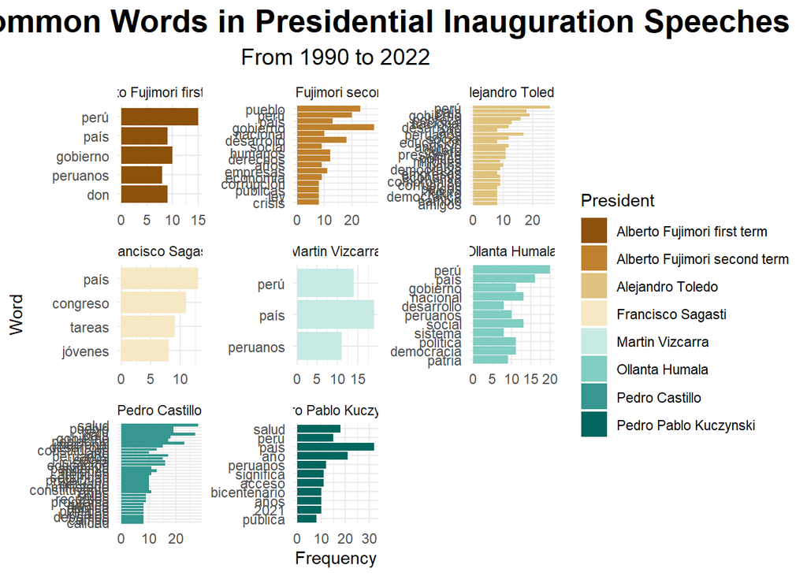

```r
df_tokenized %>%
  count(president,
    word,
    sort = TRUE
  ) %>%
  filter(n > 7) %>% # words that each president used more than 7 times
  ggplot(aes(x = reorder(word, n),
            y = n,
            fill = president)) +
  geom_col() +
    facet_wrap(~president,
    scales = "free") +
    coord_flip() +
    scale_fill_manual(values = brewer.pal(8, "BrBG")) +
    theme_minimal() +
    ggtitle("Most Common Words in Presidential Inauguration Speeches",
            subtitle = "From 1990 to 2022") +
    labs(
      x = "Word",
      y = "Frequency",
      fill = "President"
    ) +
    theme(
      plot.title = element_text(
        hjust = 0.5,
        size = 20,
        face = "bold"
      ),
      plot.subtitle = element_text(
        hjust = 0.5,
        size = 14
      )
    )
```

## N-grams

The most common bigrams were be analyzed. Below are the top 20 bigrams:

```r
df_no_stopwords %>%
  unnest_tokens(bigram,
                clean_speech,
                token = "ngrams",
                n = 2) %>%
  filter(!is.na(bigram)) %>%
  count(bigram, sort = TRUE) %>%
  head(20) # onyl the first 20
```

```
## # A tibble: 20 × 3
## # Groups:   president [7]
##    president                    bigram                     n
##    <chr>                        <chr>                  <int>
##  1 Alberto Fujimori second term derechos humanos          10
##  2 Pedro Pablo Kuczynski        año 2021                  10
##  3 Pedro Pablo Kuczynski        año bicentenario           9
##  4 Pedro Castillo               millones soles             8
##  5 Pedro Pablo Kuczynski        2021 año                   8
##  6 Pedro Castillo               asamblea constituyente     6
##  7 Pedro Pablo Kuczynski        salud pública              6
##  8 Alberto Fujimori first term  año 2000                   5
##  9 Alberto Fujimori second term empresas públicas          5
## 10 Alberto Fujimori second term proyecto ley               5
## 11 Alejandro Toledo             amigas amigos              5
## 12 Alejandro Toledo             fuerzas armadas            5
## 13 Francisco Sagasti            mesa directiva             5
## 14 Ollanta Humala               inclusión social           5
## 15 Pedro Castillo               fuerzas armadas            5
## 16 Pedro Castillo               protección social          5
## 17 Pedro Castillo               pueblo peruano             5
## 18 Pedro Pablo Kuczynski        país moderno               5
## 19 Alberto Fujimori first term  generación empleos         4
## 20 Alberto Fujimori first term  revolución productiva      4
```

Similar to what has already been mentioned, the reference to human rights (*derechos humanos*) is constant in the discourse of Alberto Fujimori’s second term. Without reading his speech, but knowing in broad terms the reasons for which he is accused, one might think that in his speech he was already defending himself against accusations of human rights violations.

Probably, PPK mentioned the bigrams *año 2021* (year 2021) and *año Bicentenario* (Bicentennial year) many times because, upon taking office in 2016, he was excited to be the president in office in 2021, the year of the the Bicentennial of Peru’s Independence. However, he resigned from office much earlier for disputes with the congress.

On the other hand, the *asamblea constityente* (Constituent Assembly) was Pedro Castillo’s main campaign promise to reform the constitution.

Another important feature is the mention of social issues by the two presidents who took office after running for the left: Ollanta Humala —although he later made a neoliberal right-wing government— and Pedro Castillo. The former spoke repeatedly about *inclusión social* (social inclusion), and the latter about *protección social* (social protection).

Below are the top 2 bigrams for each president. However, since there are many bigrams that are repeated an equal number of times, there are many ties in the top 2, so more bigrams are actually shown.

```r
bigrams <-  df_no_stopwords %>%
  unnest_tokens(bigram,
                clean_speech,
                token = "ngrams",
                n = 2)

# bigrams by president
bigram_counts <- bigrams %>%
  count(president,
        bigram,
        sort = TRUE)

# top bigrams for each president
top_bigrams <- bigram_counts %>%
  group_by(president) %>%
  top_n(2, n) %>% # only the top 2, although there are many ties
  arrange(president)

top_bigrams
```

```
## # A tibble: 30 × 3
## # Groups:   president [10]
##    president                    bigram                    n
##    <chr>                        <chr>                 <int>
##  1 Alberto Fujimori first term  año 2000                  5
##  2 Alberto Fujimori first term  generación empleos        4
##  3 Alberto Fujimori first term  revolución productiva     4
##  4 Alberto Fujimori second term derechos humanos         10
##  5 Alberto Fujimori second term empresas públicas         5
##  6 Alberto Fujimori second term proyecto ley              5
##  7 Alejandro Toledo             amigas amigos             5
##  8 Alejandro Toledo             fuerzas armadas           5
##  9 Dina Boluarte                alta responsabilidad      3
## 10 Dina Boluarte                señoras señores           3
## # … with 20 more rows
```

The following graph shows the most common bigrams. However, the plot does not show well in the inline preview. Please, click in “Show in New window” button for it to be better displayed:

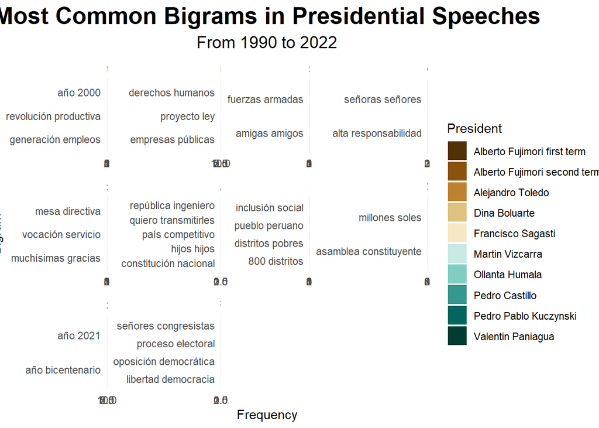

```r
ggplot(top_bigrams,
       aes(x = reorder(bigram, n),
           y = n,
           fill = president)) +
  geom_col() +
  facet_wrap(~ president,
             scales = "free") +
  coord_flip() +
  scale_fill_manual(values = brewer.pal(10, "BrBG")) +
  theme_minimal() +
  ggtitle("Most Common Bigrams in Presidential Speeches",
          subtitle = "From 1990 to 2022") +
  labs(x = "Bigram",
       y = "Frequency",
       fill = "President") +
  theme(plot.title = element_text(hjust = 0.5,
                                  size = 20,
                                  face = "bold"),
        plot.subtitle = element_text(hjust = 0.5,
                                     size = 14))
```

Next, the most common trigrams were identified:

```r
df_no_stopwords %>%
  unnest_tokens(trigram,
                clean_speech,
                token = "ngrams",
                n = 3) %>%
  filter(!is.na(trigram)) %>%
  count(trigram, sort = TRUE) %>%
  head(20) # only the first 20
```

```
## # A tibble: 20 × 3
## # Groups:   president [5]
##    president                    trigram                                n
##    <chr>                        <chr>                              <int>
##  1 Pedro Pablo Kuczynski        2021 año bicentenario                  8
##  2 Pedro Pablo Kuczynski        año 2021 año                           8
##  3 Alejandro Toledo             siente anhelo profundo                 4
##  4 Pedro Pablo Kuczynski        país moderno significa                 4
##  5 Alberto Fujimori second term central empresas públicas              3
##  6 Alejandro Toledo             fuerzas armadas policiales             3
##  7 Pedro Castillo               mil millones soles                     3
##  8 Alberto Fujimori first term  métodos planificación familiar         2
##  9 Alberto Fujimori first term  pobreza año 2000                       2
## 10 Alberto Fujimori first term  revolución productiva pequeños         2
## 11 Alberto Fujimori second term comunidad financiera internacional     2
## 12 Alberto Fujimori second term gobierno central empresas              2
## 13 Alberto Fujimori second term grave crisis económica                 2
## 14 Alberto Fujimori second term grupos alzados armas                   2
## 15 Alberto Fujimori second term lema honradez tecnología               2
## 16 Alberto Fujimori second term respeto derechos humanos               2
## 17 Alejandro Toledo             anhelo profundo país                   2
## 18 Alejandro Toledo             anhelo profundo pueblo                 2
## 19 Alejandro Toledo             autoridad alto nivel                   2
## 20 Alejandro Toledo             cambio amigas amigos                   2
```

In the case of PPK, references to the year 2021 as the year of the Bicentennial of the Independence of Peru are repeated. However, the theme of *país moderno significa*, alluding to an idea of “modernization”, is also very present. It could be thought that his allusion to modernization was in response to one of the main criticisms against him during his campaign: that he is an “old school” politician who has been decades without making a significant contribution to the country from his positions in the executive and legislative offices, and that he is too old to assume the presidency. In fact, one of his campaign slogans was *Me hago viejo esperando* (“I grow old waiting”), responding to criticism about his advanced age.

By arranging the trigrams by president in alphabetical order, we also get an idea of the general theme of their speeches. Fujimori, who we have already mentioned is in prison for human rights violations, including the forced sterilization of thousands of indigenous, poor and Quechua-speaking women as a method to contain poverty, in his first term spoke about “family planning” and “poverty”. In his second term, he spoke about *respeto derechos humanos* “respect for human rights”. Another very important topic in his speech is related to productivity, the role of companies in economic development, the economic crisis of that time and terrorism (when he mentions *grupos alzados armas*, “the armed groups”).

On the contrary, Alejandro Toledo does not show any very relevant trigram, except his mention to the armed and police forces. On the other hand, Dina Boluarte does not have a predominant trigram: all of them are repeated only once, and that is the reason the table below is cluttered. It is to be anticipated, because she took office with only hours of notice, and, therefore, it is expected that she has not had a very structured speech. Similar happens with Martin Vizcarra and Valentin Paniagua.

```r
trigrams <-  df_no_stopwords %>%
  unnest_tokens(trigram,
                clean_speech,
                token = "ngrams",
                n = 3)

# trigrams by president
trigram_counts <- trigrams %>%
  count(president,
        trigram,
        sort = TRUE)

# top trigrams for each president
top_trigrams <- trigram_counts %>%
  group_by(president) %>%
  top_n(2, n) %>%
  arrange(president)

top_trigrams
```

```
## # A tibble: 1,191 × 3
## # Groups:   president [10]
##    president                    trigram                                n
##    <chr>                        <chr>                              <int>
##  1 Alberto Fujimori first term  métodos planificación familiar         2
##  2 Alberto Fujimori first term  pobreza año 2000                       2
##  3 Alberto Fujimori first term  revolución productiva pequeños         2
##  4 Alberto Fujimori second term central empresas públicas              3
##  5 Alberto Fujimori second term comunidad financiera internacional     2
##  6 Alberto Fujimori second term gobierno central empresas              2
##  7 Alberto Fujimori second term grave crisis económica                 2
##  8 Alberto Fujimori second term grupos alzados armas                   2
##  9 Alberto Fujimori second term lema honradez tecnología               2
## 10 Alberto Fujimori second term respeto derechos humanos               2
## # … with 1,181 more rows
```

As can be seen in the graph above, their bar graphs are almost unreadable. Thus, the trigram analysis gives us an idea of who took office on an emergency basis. If not shown correctly, please, open the graph in a new window.

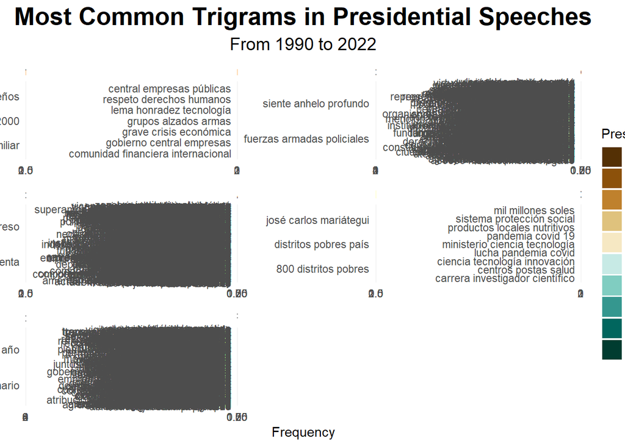

```r
ggplot(top_trigrams,
       aes(x = reorder(trigram, n),
           y = n,
           fill = president)) +
  geom_col() +
  facet_wrap(~ president,
             scales = "free") +
  coord_flip() +
  scale_fill_manual(values = brewer.pal(10, "BrBG")) +
  theme_minimal() +
  ggtitle("Most Common Trigrams in Presidential Speeches",
          subtitle = "From 1990 to 2022") +
  labs(x = "Trigram",
       y = "Frequency",
       fill = "President") +
  theme(plot.title = element_text(hjust = 0.5,
                                  size = 20,
                                  face = "bold"),
        plot.subtitle = element_text(hjust = 0.5,
                                     size = 14))
```

## Sentiment analysis

A sentiment analysis of the speeches was also performed. For this purpose, other packages than those seen in class were used. The reason behind this was that sentiment analysis assigns a label —of level of polarization or sentiment— to words that are used based on lexicons. However, the packages discussed in class are more intended for use with English corpora. Thus, in this section, after searching and testing with other packages, the packages `SentimentAnalysis` and `syuzhet` were employed. Yet, they may not be as good as those based on English lexicons, which are much more developed.

The next chunk employs the `SentimentAnalysis` pacakge and may take up to 30 seconds to run:

```r
sentiments_spanish <- analyzeSentiment(df_tokenized$word,
  language = "spanish",
  stemming = TRUE
)
head(sentiments_spanish)
```

```
##   WordCount SentimentGI NegativityGI PositivityGI SentimentHE NegativityHE
## 1         1           0            0            0           0            0
## 2         1           0            0            0           0            0
## 3         1           0            0            0           0            0
## 4         1           0            0            0           0            0
## 5         1           0            0            0           0            0
## 6         1           0            0            0           0            0
##   PositivityHE SentimentLM NegativityLM PositivityLM RatioUncertaintyLM
## 1            0           0            0            0                  0
## 2            0           0            0            0                  0
## 3            0           0            0            0                  0
## 4            0           0            0            0                  0
## 5            0           0            0            0                  0
## 6            0           0            0            0                  0
##   SentimentQDAP NegativityQDAP PositivityQDAP
## 1             0              0              0
## 2             0              0              0
## 3             0              0              0
## 4             0              0              0
## 5             0              0              0
## 6             0              0              0
```

The following is to view sentiment direction (i.e. positive, neutral and negative), as a way to summarize a bit the prior results:

```r
df_sentiments <- data.frame(df_tokenized$word,
  sentiment = convertToDirection(sentiments_spanish$SentimentGI))

head(df_sentiments, 20)
```

```
##    df_tokenized.word sentiment
## 1           voluntad   neutral
## 2           soberana   neutral
## 3             pueblo   neutral
## 4          expresada   neutral
## 5            limpias   neutral
## 6       democráticas   neutral
## 7         elecciones   neutral
## 8            consuma   neutral
## 9          iniciarse   neutral
## 10          gobierno   neutral
## 11           empieza   neutral
## 12           mejores   neutral
## 13         auspicios   neutral
## 14      consecuencia   neutral
## 15          economía   neutral
## 16           estable   neutral
## 17             orden   neutral
## 18            social   neutral
## 19        recuperado   neutral
## 20             honor  positive
```

With the following, the sentiments of the presidential messages in general are further summarized:

```r
table(df_sentiments$sentiment)
```

```
##
## negative  neutral positive
##       56    12834      205
```

As can be seen, the vast majority of words were classified as neutral. This includes nouns such as “country”, or numbers such as 2021.

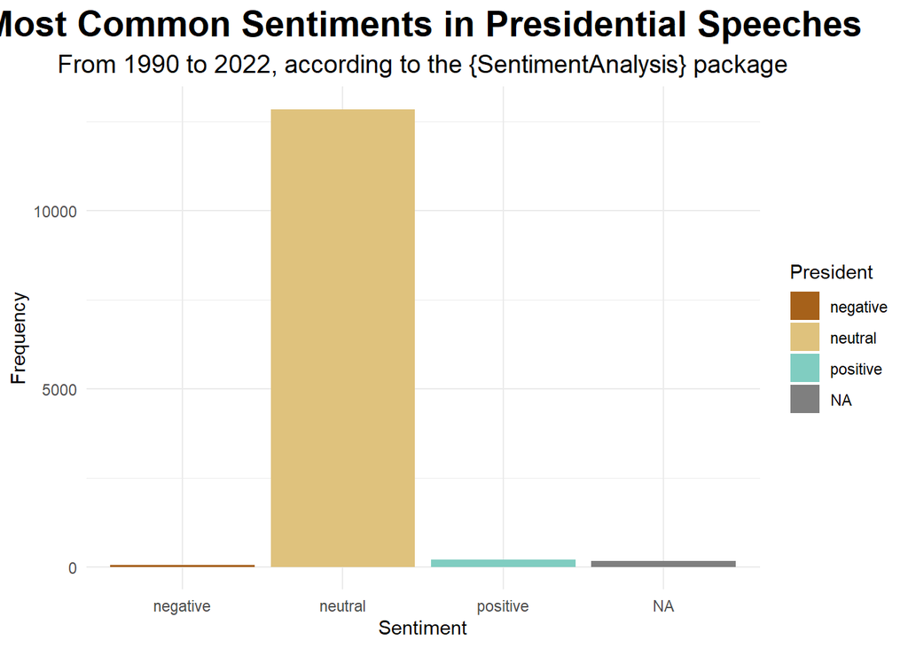

```r
df_sentiments %>%
  group_by(sentiment) %>%
  summarise(number = n()) %>%
  ggplot(aes(x = sentiment,
            y=number)) +
  geom_bar(aes(fill=sentiment),
              stat = "identity") +
  scale_fill_manual(values = brewer.pal(4, "BrBG")) +
  theme_minimal() +
  ggtitle("Most Common Sentiments in Presidential Speeches",
          subtitle = "From 1990 to 2022, according to the {SentimentAnalysis} package") +
  labs(x = "Sentiment",
       y = "Frequency",
       fill = "President") +
  theme(plot.title = element_text(hjust = 0.5,
                                  size = 20,
                                  face = "bold"),
        plot.subtitle = element_text(hjust = 0.5,
                                     size = 14))
```

These results were contrasted with the `syuzhet` package. This package associates texts to 8 emotions and 2 feelings. The more the value exceeds 0, the more pronounced the emotion or feeling is.

However, it was noticed that using this package required much computational power and took a long time. For that reason, some memory was freed with the `gc()` function and the process was parallelized. The parallel computing approach consists of distributing tasks that do not need to be sequential, for them to be executed in a parallel way. Therefore, more than one core can be used —in this case, the laptop on which this exercise was done has 8— to execute the task. This process could potentially be parallelized on 8 threads, but in the interest of making this code reproducible since not every computer has this number of cores, only 4 were harnessed.

It is also recommended closing other programs that are not being used.

```r
gc()
```

```
##           used  (Mb) gc trigger   (Mb)  max used  (Mb)
## Ncells 3406617 182.0    6580821  351.5   6580821 351.5
## Vcells 6388022  48.8  149320688 1139.3 130559861 996.1
```

```r
cl <- makeCluster(4)
clusterExport(cl = cl, c("get_sentiment",
                         "get_sent_values",
                         "get_nrc_sentiment",
                         "get_nrc_values",
                         "parLapply"))
```

```r
sentiment_nrc <- get_nrc_sentiment(df_tokenized$word,
                                   cl = cl,
                                   language = "spanish")
stopCluster(cl)
```

With this approach, this computation took 1 minute and 40 secs, and almost 95% of CPU.

```r
head(sentiment_nrc)
```

```
##   anger anticipation disgust fear joy sadness surprise trust negative positive
## 1     0            0       0    0   0       0        0     0        0        0
## 2     0            0       0    0   0       0        0     0        0        0
## 3     0            0       0    0   0       0        0     0        0        0
## 4     0            0       0    0   0       0        0     0        0        0
## 5     0            0       0    0   0       0        0     0        0        0
## 6     0            0       0    0   0       0        0     0        0        0
```

A summary of the sentiments and emotions of this package can be seen. Judging by the mean, words with a positive tone are predominant:

```r
summary(sentiment_nrc)
```

```
##      anger          anticipation        disgust             fear
##  Min.   :0.00000   Min.   :0.00000   Min.   :0.00000   Min.   :0.00000
##  1st Qu.:0.00000   1st Qu.:0.00000   1st Qu.:0.00000   1st Qu.:0.00000
##  Median :0.00000   Median :0.00000   Median :0.00000   Median :0.00000
##  Mean   :0.03184   Mean   :0.04294   Mean   :0.01932   Mean   :0.04618
##  3rd Qu.:0.00000   3rd Qu.:0.00000   3rd Qu.:0.00000   3rd Qu.:0.00000
##  Max.   :4.00000   Max.   :3.00000   Max.   :3.00000   Max.   :3.00000
##       joy             sadness           surprise           trust
##  Min.   :0.00000   Min.   :0.00000   Min.   :0.00000   Min.   :0.00000
##  1st Qu.:0.00000   1st Qu.:0.00000   1st Qu.:0.00000   1st Qu.:0.00000
##  Median :0.00000   Median :0.00000   Median :0.00000   Median :0.00000
##  Mean   :0.04045   Mean   :0.03464   Mean   :0.01834   Mean   :0.09184
##  3rd Qu.:0.00000   3rd Qu.:0.00000   3rd Qu.:0.00000   3rd Qu.:0.00000
##  Max.   :3.00000   Max.   :7.00000   Max.   :2.00000   Max.   :3.00000
##     negative          positive
##  Min.   :0.00000   Min.   :0.0000
##  1st Qu.:0.00000   1st Qu.:0.0000
##  Median :0.00000   Median :0.0000
##  Mean   :0.07546   Mean   :0.1483
##  3rd Qu.:0.00000   3rd Qu.:0.0000
##  Max.   :7.00000   Max.   :4.0000
```

The order of each emotion or feeling is in alphabetical order: anger, anticipation, disgust, fear, joy, sadness, surprise, trust, negative, positive. This analysis will be done in a general sense, rather than for each president.

Hereunder, an example of 20 words associated with each emotion or feeling can be read. The list is longer, but for space reasons only 20 are shown. To see the complete list, uncomment the last line of each chunk.

```r
anger <- which(sentiment_nrc$anger > 0)
head(df_tokenized$word[anger], 20)
```

```
##  [1] "fuerza"     "pobreza"    "voto"       "injusticia" "piedra"
##  [6] "cruzada"    "falta"      "falta"      "falta"      "falta"
## [11] "juventud"   "pobreza"    "pobreza"    "pobreza"    "pobreza"
## [16] "guerra"     "guerra"     "fuerza"     "terrorismo" "perder"
```

```r
#df_tokenized$word[anger]
```

```r
anticipation <- which(sentiment_nrc$anticipation > 0)
head(df_tokenized$word[anticipation], 20)
```

```
##  [1] "paciente"      "renacimiento"  "despertar"     "voto"
##  [5] "paz"           "oportunidad"   "dispuesto"     "progreso"
##  [9] "peligro"       "anhelo"        "presente"      "mejorar"
## [13] "universidad"   "joven"         "juventud"      "independencia"
## [17] "reducir"       "continuará"    "reducir"       "ingresos"
```

```r
#df_tokenized$word[anticipation]
```

```r
disgust <- which(sentiment_nrc$disgust > 0)
head(df_tokenized$word[disgust], 20)
```

```
##  [1] "puesto"     "vanamente"  "pobreza"    "fracaso"    "interior"
##  [6] "falta"      "falta"      "falta"      "falta"      "ahorro"
## [11] "ahorro"     "ahorro"     "extranjero" "pobreza"    "pobreza"
## [16] "pobreza"    "pobreza"    "menor"      "excelencia" "congreso"
```

```r
#df_tokenized$word[disgust]
```

```r
fear <- which(sentiment_nrc$fear > 0)
head(df_tokenized$word[fear], 20)
```

```
##  [1] "gobierno"   "gobierno"   "fuerza"     "pobreza"    "fracaso"
##  [6] "gobierno"   "olvidado"   "peligro"    "gobierno"   "cruzada"
## [11] "falta"      "falta"      "falta"      "falta"      "juventud"
## [16] "extranjero" "pobreza"    "pobreza"    "pobreza"    "pobreza"
```

```r
#df_tokenized$word[fear]
```

```r
joy <- which(sentiment_nrc$joy > 0)
head(df_tokenized$word[joy], 20)
```

```
##  [1] "ceremonia"     "saludo"        "renacimiento"  "recursos"
##  [5] "riqueza"       "recursos"      "voto"          "paz"
##  [9] "progreso"      "anhelo"        "presente"      "igualdad"
## [13] "riqueza"       "mejorar"       "recursos"      "joven"
## [17] "juventud"      "independencia" "excelencia"    "recursos"
```

```r
# df_tokenized$word[joy]
```

```r
sadness <- which(sentiment_nrc$sadness > 0)
head(df_tokenized$word[sadness], 20)
```

```
##  [1] "vanamente"  "pobreza"    "fracaso"    "voto"       "olvidado"
##  [6] "injusticia" "anhelo"     "cancelará"  "fondo"      "pobreza"
## [11] "pobreza"    "pobreza"    "pobreza"    "emergencia" "ingresos"
## [16] "ingresos"   "fondo"      "destino"    "guerra"     "guerra"
```

```r
# df_tokenized$word[sadness]
```

```r
surprise <- which(sentiment_nrc$surprise > 0)
head(df_tokenized$word[surprise], 20)
```

```
##  [1] "estable"       "ceremonia"     "saludo"        "voto"
##  [5] "oportunidad"   "presente"      "joven"         "juventud"
##  [9] "independencia" "emergencia"    "destino"       "amanecer"
## [13] "amanecer"      "esperanza"     "ruptura"       "oportunidad"
## [17] "perder"        "destino"       "libertad"      "independencia"
```

```r
# df_tokenized$word[surprise]
```

```r
trust <- which(sentiment_nrc$trust > 0)
head(df_tokenized$word[trust], 20)
```

```
##  [1] "estable"      "honor"        "don"          "don"          "don"
##  [6] "don"          "don"          "don"          "don"          "don"
## [11] "don"          "fuerza"       "renacimiento" "recursos"     "riqueza"
## [16] "eficaz"       "recursos"     "real"         "voto"         "base"
```

```r
# df_tokenized$word[trust]
```

```r
negative <- which(sentiment_nrc$negative > 0)
head(df_tokenized$word[negative], 20)
```

```
##  [1] "gobierno"   "maría"      "gobierno"   "fuerza"     "vanamente"
##  [6] "pobreza"    "fracaso"    "voto"       "gobierno"   "olvidado"
## [11] "barro"      "injusticia" "peligro"    "anhelo"     "piedra"
## [16] "gobierno"   "cruzada"    "cancelará"  "servirán"   "esfuerzos"
```

```r
# df_tokenized$word[negative]
```

```r
positive <- which(sentiment_nrc$positive > 0)
head(df_tokenized$word[positive], 20)
```

```
##  [1] "estable"      "honor"        "ceremonia"    "saludo"       "presencia"
##  [6] "don"          "don"          "don"          "don"          "maría"
## [11] "don"          "don"          "don"          "don"          "don"
## [16] "paciente"     "tarea"        "construir"    "fuerza"       "renacimiento"
```

```r
#df_tokenized$word[positive]
```

As can be seen next, in an aggregated manner, the “positive” and “trust” words are the most used by Peruvian presidents in recent years, followed by the negative words —these are almost half of the positive ones—, and the words denoting “fear” and “anticipation”:

```r
sentiment_nrc %>%
  summarise_all(sum) %>%
  gather(key = sentiment,
         value = number) %>%
  arrange(desc(number))
```

```
##       sentiment number
## 1      positive   1965
## 2         trust   1217
## 3      negative   1000
## 4          fear    612
## 5  anticipation    569
## 6           joy    536
## 7       sadness    459
## 8         anger    422
## 9       disgust    256
## 10     surprise    243
```

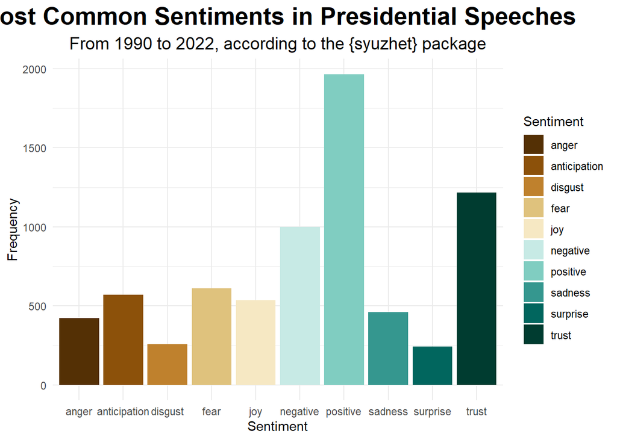

```r
sentiment_nrc %>%
  summarise_all(sum) %>%
  gather(key = sentiment,
         value = number) %>%
  ggplot(aes(x = sentiment,
             y = number,
             fill = sentiment)) +
  geom_bar(stat = "identity") +
  scale_fill_manual(values = brewer.pal(10, "BrBG")) +
  theme_minimal() +
  ggtitle("Most Common Sentiments in Presidential Speeches",
          subtitle = "From 1990 to 2022, according to the {syuzhet} package") +
  labs(x = "Sentiment",
       y = "Frequency",
       fill = "Sentiment") +
  theme(plot.title = element_text(hjust = 0.5,
                                  size = 20,
                                  face = "bold"),
        plot.subtitle = element_text(hjust = 0.5,
                                     size = 14))
```

## Topic modelling

Next, topic modelling was conducted. According to Silge and Robinson (2017), Latent Dirichlet allocation (LDA) is one of the most common algorithms for it. It is guided by two principles: - each document is a mixture of topics, and - every topic is a mixture of words (Silge and Robinson, 2017).

The authors comment that LDA is a mathematical method for estimating both at the same time. In this way, associations between the discourses can be found.

The first step towards LDA was to turn the dataframe into a DocumentTermMatrix (DTM).

```r
df_dtm <- df_tokenized %>%
  count(president, word) %>%
  cast_dtm(president, word, n)

class(df_dtm) # to verify it is of class "DocumentTermMatrix"
```

```
## [1] "DocumentTermMatrix"    "simple_triplet_matrix"
```

```r
df_dtm
```

```
## <<DocumentTermMatrix (documents: 10, terms: 5171)>>
## Non-/sparse entries: 8523/43187
## Sparsity           : 84%
## Maximal term length: 20
## Weighting          : term frequency (tf)
```

Later, a fixed number of topics to be found was established. For no particular reason, it was chosen to find 5.

```r
df_lda_5 <- LDA(df_dtm,
              k = 5,
              control = list(seed = 666))
df_lda_5
```

```
## A LDA_VEM topic model with 5 topics.
```

At this point, even though no output could be read, the model was already declared.

```r
df_lda_topics_5 <- tidy(df_lda_5,
                      matrix = "beta")

df_lda_topics_5
```

```
## # A tibble: 25,855 × 3
##    topic term      beta
##    <int> <chr>    <dbl>
##  1     1 1,300 2.83e-63
##  2     2 1,300 4.65e- 4
##  3     3 1,300 6.96e-65
##  4     4 1,300 3.73e-63
##  5     5 1,300 3.96e-65
##  6     1 10    1.19e-59
##  7     2 10    4.65e- 4
##  8     3 10    5.98e-64
##  9     4 10    1.88e- 3
## 10     5 10    1.48e-60
## # … with 25,845 more rows
```

Note that numbers appeared first in the “term” column. This could be confusing. However, starting from page 4 of the results the terms were shown. Therefore, at this point, numbers were deleted from the corpus, always taking into consideration that there were some numbers, such as 2021, that were important in the presidential speeches.

```r
sum(str_detect(df_tokenized$word, "^\\d+(,\\d{3})*(\\.\\d+)?$")) #to identify numbers before deleting them
```

```
## [1] 135
```

```r
df_tokenized_no_numbers <- df_tokenized %>%
  filter(!str_detect(word, "^\\d+(,\\d{3})*(\\.\\d+)?$"))

sum(str_detect(df_tokenized_no_numbers$word, "^\\d+(,\\d{3})*(\\.\\d+)?$")) # to check that we have effectively deleted them
```

```
## [1] 0
```

A new DTM was created, overwriting the first one:

```r
df_dtm <- df_tokenized_no_numbers %>%
  count(president, word) %>%
  cast_dtm(president, word, n)

class(df_dtm)
```

```
## [1] "DocumentTermMatrix"    "simple_triplet_matrix"
```

```r
df_dtm
```

```
## <<DocumentTermMatrix (documents: 10, terms: 5089)>>
## Non-/sparse entries: 8419/42471
## Sparsity           : 83%
## Maximal term length: 20
## Weighting          : term frequency (tf)
```

### 5 topics LDA

Then, the same model was declared and probabilities of each word to be part of any topic were calculated:

```r
df_lda_5 <- LDA(df_dtm,
              k = 5,
              control = list(seed = 666))
df_lda_5
```

```
## A LDA_VEM topic model with 5 topics.
```

```r
df_lda_topics_5 <- tidy(df_lda_5,
                      matrix = "beta")

df_lda_topics_5
```

```
## # A tibble: 25,445 × 3
##    topic term       beta
##    <int> <chr>     <dbl>
##  1     1 abrir  5.37e-49
##  2     2 abrir  5.51e- 4
##  3     3 abrir  4.14e- 4
##  4     4 abrir  5.40e- 4
##  5     5 abrir  1.48e-63
##  6     1 acceso 1.93e- 3
##  7     2 acceso 8.27e- 4
##  8     3 acceso 4.97e- 3
##  9     4 acceso 1.08e- 3
## 10     5 acceso 1.42e- 3
## # … with 25,435 more rows
```

This gave the probability for each word to belong to each topic. Below are the first 20 words for each of the 5 topics.

```r
top_terms_topic_5 <- df_lda_topics_5 %>%
  group_by(topic) %>%
  top_n(20, beta) %>%
  ungroup() %>%
  arrange(topic, -beta)

top_terms_topic_5
```

```
## # A tibble: 115 × 3
##    topic term         beta
##    <int> <chr>       <dbl>
##  1     1 salud     0.00901
##  2     1 país      0.00869
##  3     1 nacional  0.00740
##  4     1 perú      0.00611
##  5     1 pueblo    0.00611
##  6     1 gobierno  0.00579
##  7     1 peruanos  0.00547
##  8     1 población 0.00547
##  9     1 educación 0.00515
## 10     1 sistema   0.00515
## # … with 105 more rows
```

In topic 1, the most likely word is *salud*, followed by *país* (country) and *nacional* (national). Other topics are Peru, *pueblo* and *gobierno* (government). Topic 2 is characterized by topics such as *pobreza* (poverty), *desarrollo* (development), *future* (future) and *educación* (education). Topic 3 talks also about *salud*, *año* (year), *bicentenario* (Bicentennial, probably regarding the 200 aniversary of Peru independence in 2021) and *jóvenes* (youth). Topic 4 coincides with some of the previous topics in terms of *social*, Peru, but also mentions *democracia* (democracy) and *patria*, *crecimiento* (growth), *sistema* (system), etc. Finally, topic 5 is related to *gobierno*, *desarrollo* (development), *derechos* (rights), *corrupción* (corruption), *empresas* (companies), etc. However, in almost all topics the first general words are repeated: *país*, Peru y *nacional*.

If the following graphic is not clearly visible, I would appreciate it if you could enlarge it by opening it in a separate window:

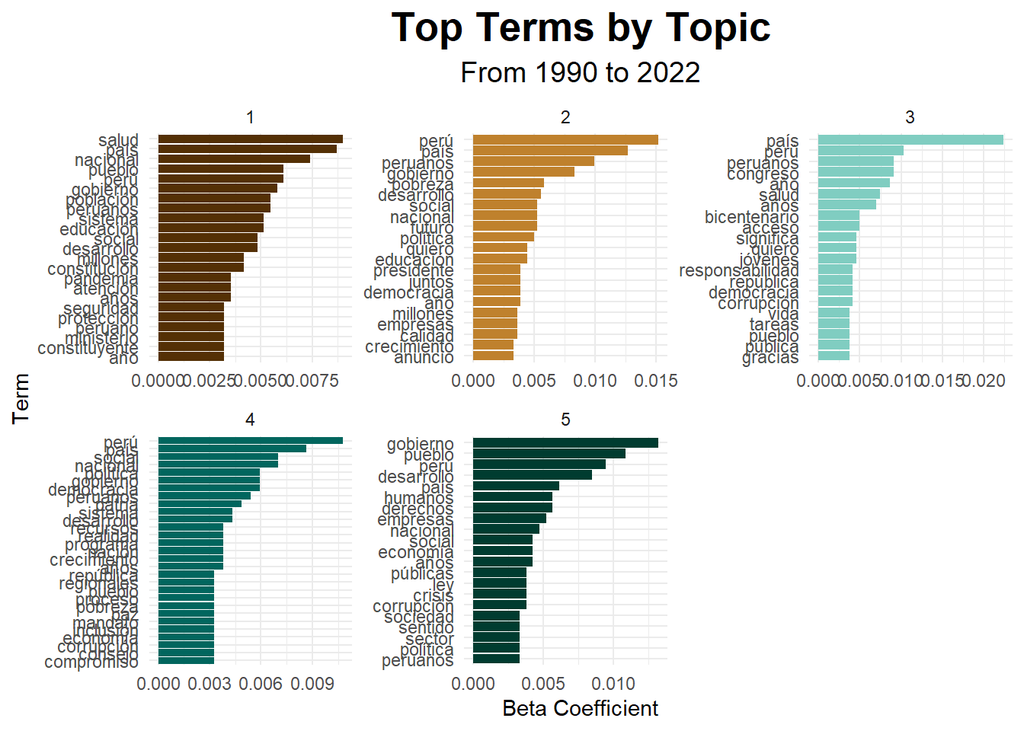

```r
colors_5 <- c("#543005", "#bf812d", "#80cdc1", "#01665e", "#003c30")

top_terms_topic_5 %>%
  mutate(term = reorder_within(term, beta, topic)) %>%
  ggplot(aes(beta, term,
             fill = factor(topic))) +
  geom_col(show.legend = FALSE) +
  facet_wrap(~ topic,
             scales = "free") +
  scale_y_reordered() +
  scale_fill_manual(values = colors_5) +
  theme_minimal() +
  ggtitle("Top Terms by Topic",
          subtitle = "From 1990 to 2022") +
  labs(
      x = "Beta Coefficient",
      y = "Term",
      fill = "Topic"
      ) +
  theme(
        plot.title = element_text(
                      hjust = 0.5,
                      size = 20,
                      face = "bold"
                      ),
        plot.subtitle = element_text(
                        hjust = 0.5,
                        size = 14
                        ),
        legend.position = "bottom"
        )
```

Next, the probability to each presidential speech of belonging to each topic was assigned:

```r
document_topic_prob_5 <- tidy(df_lda_5,
                            matrix = "gamma")

document_topic_prob_5
```

```
## # A tibble: 50 × 3
##    document                     topic     gamma
##    <chr>                        <int>     <dbl>
##  1 Alberto Fujimori first term      1 0.0000219
##  2 Alberto Fujimori second term     1 0.0000119
##  3 Alejandro Toledo                 1 0.0000128
##  4 Dina Boluarte                    1 0.0000849
##  5 Francisco Sagasti                1 0.0000469
##  6 Martin Vizcarra                  1 0.0000497
##  7 Ollanta Humala                   1 0.0000136
##  8 Pedro Castillo                   1 1.00
##  9 Pedro Pablo Kuczynski            1 0.0000206
## 10 Valentin Paniagua                1 0.0000702
## # … with 40 more rows
```

For example, it seemed that Pedro Castillo was the most likely to belong to this the first topic. The speech of Alberto Fujimori in his first speech, and the ones of Alejandro Toledo and Martín Vizcarra were the most likely to belong to topic 2. Dina Boluarte, Francisco Sagasti, PPK and Valentín Paniagua belong to topic 3. In the case of Sagasti and PPK, it also made sense that they were together, since they assumed their positions as part of the same party. On other hand, it seemed that only Ollanta Humala speech was part of topic 4. Similar case is that on the speech of Fujimori in his second term, which is alone in the fifth topic.

In the table below, the probability of fitting in one of the topics, together with the original speech, is shown.

```r
document_topic_merged_5 <- df %>%
  left_join(document_topic_prob_5,
    by = c("president" = "document")
  )
document_topic_merged_5
```

```
## # A tibble: 50 × 5
##    president      date       speech                                topic   gamma
##    <chr>          <chr>      <chr>                                 <int>   <dbl>
##  1 Dina Boluarte  2022-12-07 "Señoras y señores congresistas, que…     1 8.49e-5
##  2 Dina Boluarte  2022-12-07 "Señoras y señores congresistas, que…     2 8.49e-5
##  3 Dina Boluarte  2022-12-07 "Señoras y señores congresistas, que…     3 1.00e+0
##  4 Dina Boluarte  2022-12-07 "Señoras y señores congresistas, que…     4 8.49e-5
##  5 Dina Boluarte  2022-12-07 "Señoras y señores congresistas, que…     5 8.49e-5
##  6 Pedro Castillo 2021-07-28 "Mujeres y hombres de mi amado puebl…     1 1.00e+0
##  7 Pedro Castillo 2021-07-28 "Mujeres y hombres de mi amado puebl…     2 8.12e-6
##  8 Pedro Castillo 2021-07-28 "Mujeres y hombres de mi amado puebl…     3 8.12e-6
##  9 Pedro Castillo 2021-07-28 "Mujeres y hombres de mi amado puebl…     4 8.12e-6
## 10 Pedro Castillo 2021-07-28 "Mujeres y hombres de mi amado puebl…     5 8.12e-6
## # … with 40 more rows
```

To conclude this section, if we could assign only one topic to each inaugural speech, what would it be?:

```r
president_topics_5 <- document_topic_merged_5 %>%
  group_by(president) %>%
  top_n(1, gamma) %>%
  select(president, topic)

president_topics_5
```

```
## # A tibble: 10 × 2
## # Groups:   president [10]
##    president                    topic
##    <chr>                        <int>
##  1 Dina Boluarte                    3
##  2 Pedro Castillo                   1
##  3 Francisco Sagasti                3
##  4 Martin Vizcarra                  2
##  5 Pedro Pablo Kuczynski            3
##  6 Ollanta Humala                   4
##  7 Alejandro Toledo                 2
##  8 Valentin Paniagua                3
##  9 Alberto Fujimori second term     5
## 10 Alberto Fujimori first term      2
```

### 2 topics LDA

However, there were very similar topics. Maybe 5 was a large number. We then reduced the number of topics to 2, with the hypothesis that this would help make the themes of each topic more distinct. The exercise was very similar. First, the model was declared:

```r
df_lda_2 <- LDA(df_dtm,
              k = 2,
              control = list(seed = 666))
df_lda_2
```

```
## A LDA_VEM topic model with 2 topics.
```

Then, a probability to each word was assigned:

```r
df_lda_topics_2 <- tidy(df_lda_2,
                      matrix = "beta")

df_lda_topics_2
```

```
## # A tibble: 10,178 × 3
##    topic term            beta
##    <int> <chr>          <dbl>
##  1     1 abrir       0.000356
##  2     2 abrir       0.000267
##  3     1 acceso      0.00160
##  4     2 acceso      0.00227
##  5     1 acciones    0.000712
##  6     2 acciones    0.00147
##  7     1 acción      0.000712
##  8     2 acción      0.000933
##  9     1 aceleración 0.000178
## 10     2 aceleración 0.000133
## # … with 10,168 more rows
```

Later, the 20 most probable words for each topic were found. This could help understand what is each topic about.

```r
top_terms_topic_2 <- df_lda_topics_2 %>%
  group_by(topic) %>%
  top_n(20, beta) %>%
  ungroup() %>%
  arrange(topic, -beta)

top_terms_topic_2
```

```
## # A tibble: 40 × 3
##    topic term          beta
##    <int> <chr>        <dbl>
##  1     1 país       0.00926
##  2     1 perú       0.00855
##  3     1 nacional   0.00695
##  4     1 peruanos   0.00623
##  5     1 salud      0.00570
##  6     1 pueblo     0.00570
##  7     1 gobierno   0.00570
##  8     1 social     0.00534
##  9     1 sistema    0.00427
## 10     1 desarrollo 0.00410
## # … with 30 more rows
```

The following plot reveals which themes are covered in each topic. In a broad sense, although there are some words that are repeated —such as *país*, Perú, *peruanos*, *nacional*, etc.—, it seems that the first topic covers more politics areas and the second one covers just a bit more socio-economic ideas. For example, the first is about *gobierno*, *política*, *patria*, *república* , and others. The second addresses *salud* (even if the first topic also covers it), *empresa* and *pobreza*, *derechos* and *futuro* issues. However, the boundaries are unclear.

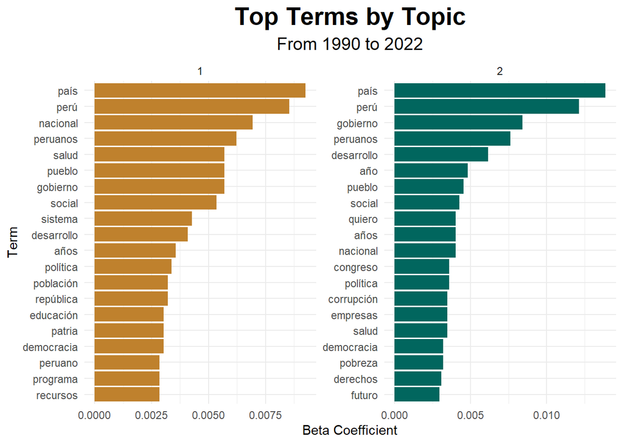

```r
colors2 <- c( "#bf812d", "#01665e")

top_terms_topic_2 %>%
  mutate(term = reorder_within(term, beta, topic)) %>%
  ggplot(aes(beta, term,
             fill = factor(topic))) +
  geom_col(show.legend = FALSE) +
  facet_wrap(~ topic,
             scales = "free") +
  scale_y_reordered() +
  scale_fill_manual(values = colors2) +
  theme_minimal() +
  ggtitle("Top Terms by Topic",
          subtitle = "From 1990 to 2022") +
  labs(
      x = "Beta Coefficient",
      y = "Term",
      fill = "Topic"
      ) +
  theme(
        plot.title = element_text(
                      hjust = 0.5,
                      size = 20,
                      face = "bold"
                      ),
        plot.subtitle = element_text(
                        hjust = 0.5,
                        size = 14
                        ),
        legend.position = "bottom"
        )
```

Below it can be seen which speech (and therefore, which president) could be classified in each cluster. The speeches of Dina Boluarte, Ollanta Humala, Pedro Castillo and Valentín Paniagua were more likely to be classified in the first cluster. The three presidents in the sample who took office with a leftist rhetoric were included in this cluster: Boluarte was the vice-president of Castillo, the rural left-wing rural leader, and Humala entered with a leftist discourse, although his mandate was more right-wing. These are accompanied in the same topic with Valentín Paniagua, the transitional president who was only in office for a few months after Fujimori’s resignation and which meant the return of democracy.

On the other hand, the two speeches of dictator Alberto Fujimori (quite obviously), the one by Alejandro Toledo, and the ones by Sagasti, Vizcarra and PPK were more likely to enter the 2nd topic. They were all from the right-wing, neoliberal side of the political spectrum. It is not surprising that the two speeches of Alberto Fujimori entered together in this topic, nor that Sagasti, Vizcarra and PPK were also stick: they three were from the same party. In fact, PPK was elected, but resigned and his vice-president, Vizcarra, took office. Later, he was removed from the presidency and 5 days later Sagasti occupied the position. Regarding their speeches, PPK’s focus on economic, business and productivity issues coincides with Fujimori’s emphasis on his repeated phrase “the productive revolution of the little ones”.

```r
document_topic_prob_2 <- tidy(df_lda_2,
                            matrix = "gamma")

document_topic_prob_2
```

```
## # A tibble: 20 × 3
##    document                     topic     gamma
##    <chr>                        <int>     <dbl>
##  1 Alberto Fujimori first term      1 0.0000295
##  2 Alberto Fujimori second term     1 0.0000161
##  3 Alejandro Toledo                 1 0.0000173
##  4 Dina Boluarte                    1 1.00
##  5 Francisco Sagasti                1 0.0000631
##  6 Martin Vizcarra                  1 0.0000670
##  7 Ollanta Humala                   1 1.00
##  8 Pedro Castillo                   1 1.00
##  9 Pedro Pablo Kuczynski            1 0.0000278
## 10 Valentin Paniagua                1 1.00
## 11 Alberto Fujimori first term      2 1.00
## 12 Alberto Fujimori second term     2 1.00
## 13 Alejandro Toledo                 2 1.00
## 14 Dina Boluarte                    2 0.000114
## 15 Francisco Sagasti                2 1.00
## 16 Martin Vizcarra                  2 1.00
## 17 Ollanta Humala                   2 0.0000184
## 18 Pedro Castillo                   2 0.0000109
## 19 Pedro Pablo Kuczynski            2 1.00
## 20 Valentin Paniagua                2 0.0000946
```

```r
document_topic_merged_2 <- df %>%
  left_join(document_topic_prob_2,
    by = c("president" = "document")
  )
document_topic_merged_2
```

```
## # A tibble: 20 × 5
##    president                    date       speech                  topic   gamma
##    <chr>                        <chr>      <chr>                   <int>   <dbl>
##  1 Dina Boluarte                2022-12-07 "Señoras y señores con…     1 1.00e+0
##  2 Dina Boluarte                2022-12-07 "Señoras y señores con…     2 1.14e-4
##  3 Pedro Castillo               2021-07-28 "Mujeres y hombres de …     1 1.00e+0
##  4 Pedro Castillo               2021-07-28 "Mujeres y hombres de …     2 1.09e-5
##  5 Francisco Sagasti            2020-11-17 "Queridos compatriotas…     1 6.31e-5
##  6 Francisco Sagasti            2020-11-17 "Queridos compatriotas…     2 1.00e+0
##  7 Martin Vizcarra              2018-03-23 "Queridos hermanos per…     1 6.70e-5
##  8 Martin Vizcarra              2018-03-23 "Queridos hermanos per…     2 1.00e+0
##  9 Pedro Pablo Kuczynski        2016-07-28 "Me presento ante el p…     1 2.78e-5
## 10 Pedro Pablo Kuczynski        2016-07-28 "Me presento ante el p…     2 1.00e+0
## 11 Ollanta Humala               2011-07-28 "Recibo con humildad y…     1 1.00e+0
## 12 Ollanta Humala               2011-07-28 "Recibo con humildad y…     2 1.84e-5
## 13 Alejandro Toledo             2001-07-28 "Hermanas y hermanos d…     1 1.73e-5
## 14 Alejandro Toledo             2001-07-28 "Hermanas y hermanos d…     2 1.00e+0
## 15 Valentin Paniagua            2000-11-11 "Señores Congresistas:…     1 1.00e+0
## 16 Valentin Paniagua            2000-11-11 "Señores Congresistas:…     2 9.46e-5
## 17 Alberto Fujimori second term 1995-07-28 "Al iniciar este Mensa…     1 1.61e-5
## 18 Alberto Fujimori second term 1995-07-28 "Al iniciar este Mensa…     2 1.00e+0
## 19 Alberto Fujimori first term  1990-07-28 "La voluntad soberana …     1 2.95e-5
## 20 Alberto Fujimori first term  1990-07-28 "La voluntad soberana …     2 1.00e+0
```

So, to conclude, the following table summarized more easily which topic each one would belong to, as mentioned above.

```r
president_topics_2 <- document_topic_merged_2%>%
  group_by(president) %>%
  top_n(1, gamma) %>%
  select(president, topic)

president_topics_2
```

```
## # A tibble: 10 × 2
## # Groups:   president [10]
##    president                    topic
##    <chr>                        <int>
##  1 Dina Boluarte                    1
##  2 Pedro Castillo                   1
##  3 Francisco Sagasti                2
##  4 Martin Vizcarra                  2
##  5 Pedro Pablo Kuczynski            2
##  6 Ollanta Humala                   1
##  7 Alejandro Toledo                 2
##  8 Valentin Paniagua                1
##  9 Alberto Fujimori second term     2
## 10 Alberto Fujimori first term      2
```

## Closing remarks

This analysis is far from exhaustive. However, there are some relevant insights, both in the characterization of the discourses and in the practical way of doing so.

Starting with the latter, because the texts of interest are in Spanish, translating them would have introduced errors. However, the errors that were not introduced by translation could have been introduced by the same alternative packages that were used. The fact that there are more alternatives for analyzing English texts is an undeniable truth, and the ones we used are not specific to Spanish corpora: they are packages like `SentimentAnalysis` and `syuzhet` that have additional options for setting the language to Spanish or some other language. I consider that these might be suboptimal with respect to their accuracy with English terms. In fact, at one point I tried to perform lemmatization and stemming, but I gave up on including it in this report because the words were truncated in a strange way.

Regarding the characterization of the speeches, these are full of platitudes and lack references to more concrete issues. They are more focused on the romantic than on the programmatic. Dina Boluarte’s speech is particularly scarce, as it does not even have trigrams with more than 2 appearances, and only two bigrams with more than 2 mentions, which also do not have much meaning. Another aspect, even shocking, that this analysis helped to uncover are the mentions of family planning and human rights issues by Fujimori, in his two terms in office. He, who committed atrocities in these two fields, mentioned them more frequently than others in his inaugural speeches.

Also, in terms of the sentiments of the speeches, one of the packages assigned the vast majority of words as neutral in tone. These results did not seem correct. However, an additional package was able to identify more nuances: more than 1500 tokens were identified as “positive”, being this the mode. This was followed by words classified as trust, negative, and fear. The least used were those of disgust and surprise.

## Bibliography

Mundo, Redacción BBC News. 2020. “La ola de protestas en Perú que dejó 2 muertos y 100 heridos y culminó con la renuncia del presidente.” BBC News Mundo, November 15, 2020. https://www.bbc.com/mundo/noticias-america-latina-54948270.

Olmo, Guillermo. 2022. “6 presidentes en 4 años: por qué Perú es tan difícil de gobernar.” BBC News Mundo, December 8, 2022. https://www.bbc.com/mundo/noticias-america-latina-63898035.

Rebaza, Claudia, and Jack Guy. 2023. “’They Say We’re Not Peruvian’: Protester Deaths Highlight Peru’s Deep Historical Divisions,” March 10, 2023. https://www.cnn.com/2023/03/10/americas/peru-protester-deaths-historical-divisions-intl/index.html.

Silge, Julia, and David Robinson. 2017. Text Mining with R: A Tidy Approach. First edition. Beijing ; Boston: O’Reilly.